# ancestral_state_reconstruction_analysis_of_colistin

Kyle Gontjes

2025-04-11

# Introduction

This tool’s main workhorse is the **asr()**, which leverages corHMM’s ancestral state reconstruction algorithm to characterize genome-influenced features’ gain, loss, and continuation across a phylogenetic tree.

After performing joint or ancestral state reconstruction, the resultant state predictions of ancestral nodes are parsed to generate a parent-child dataframe. By traversing the phylogenetic tree from the tips to the root, the episodes of trait gain, loss, and continuation are added to the phylogenetic tree’s edge matrix.

This information can be leveraged to infer whether an isolate belonged to a circulating trait-containing lineage (e.g., evidence of cross-transmission) or resultant from a within-host emergence event (e.g., evidence of *de novo* evolution).

To this aim, we provide a tutorial to leverage our ancestral state reconstruction wrapper function, asr(), and our tree-traversal algorithm, asr_cluster_detection(), to infer the evolutionary history of colistin, a last-resort antibiotic.

After completion of this part of the tutorial, we will be comparing the evolutionary history of this trait to 76 candidate genotypes that may be associated with our trait of interest. We will test the following genotype-phenotype associations using two functions:

1. synchronous_detection(): Calculate synchronous gain and loss events
2. downstream_gain_loss(): Calculate downstream gain and loss events

We will ask the following questions:

1. How many lineages of colistin resistant organisms exist in this population? What is the antibiotic’s dynamics of emergene and spread?
2. What genotypes are associated with resitance emergence and spread? Are there any genotypes associated with phylogenetic emergence or are there any downstream compensatory mutations?

# Tool installation:

1. Consider installing the package without vignettes, if you want to save time
2. This tool is in active development and thus please download from GitHub

```r
# Install devtools
install.packages("devtools", dep = TRUE)

# Install phyloaware from GitHub
devtools::install_github("kylegontjes/phyloAMR", force = TRUE, build_vignettes = TRUE)
```

# Environment for this tutorial

```r
library(phyloAMR)
library(dplyr)
```

```r
library(ggplot2)
library(ape)
library(ggtree)
library(hues)
library(ggnewscale)
library(pbmcapply)
library(ComplexHeatmap)
library(grid)
library(cowplot)
library(colorRamp2)
```

# Load data

This tutorial will focus on the emergence and spread of colistin non-susceptibility in a collection of 413 carbapenem-resistant *Klebsiella pneumoniae* specimens collected across 12 California long-term acute care hospitals.

We focus on the evolution and spread of non-susceptibility to colistin, a last-resort antibiotic used to treat Gram-negative bacteria.

## Dataframe

1. **tip_name_var:** variable with tip names
2. **Patient_ID:** Identifiers for patients in this study
3. **clades:** what clade of epidemic lineage sequence type 258 the isolate belongs to
4. **colistin_ns:** colistin non-susceptibility. 1 = non-susceptible. 0 = susceptible

```r
df <- phyloAMR::df
paste0("Total of 413 isolates")
```

```
#> [1] "Total of 413 isolates"
```

```r
paste0("Number of patients: ",length(unique(df$Patient_ID)))
```

```
#> [1] "Number of patients: 338"
```

```r
dim(df)
```

```
#> [1] 413   4
```

```r
paste0("View of dataframe for first 5 isolates")
```

```
#> [1] "View of dataframe for first 5 isolates"
```

```r
head(df,n = 5)
```

```
#>         tip_name_var Patient_ID    clades colistin_ns
#> PCMP_H1      PCMP_H1          1 clade IIA           0
#> PCMP_H2      PCMP_H2          2 clade IIA           0
#> PCMP_H3      PCMP_H3          3 clade IIB           1
#> PCMP_H4      PCMP_H4          4 clade IIB           0
#> PCMP_H5      PCMP_H5          5   clade I           0
```

```r
paste0("Frequency of non-susceptibility to colistin: ")
```

```
#> [1] "Frequency of non-susceptibility to colistin: "
```

```r
table(df$colistin_ns)
```

```
#>
#>   0   1
#> 277 136
```

## Phylogenetic tree

This maximum-likelihood phylogenetic tree was constructed on a Gubbins recombination filtered alignment of single-nucleotide polymorphisms using IQ-TREE

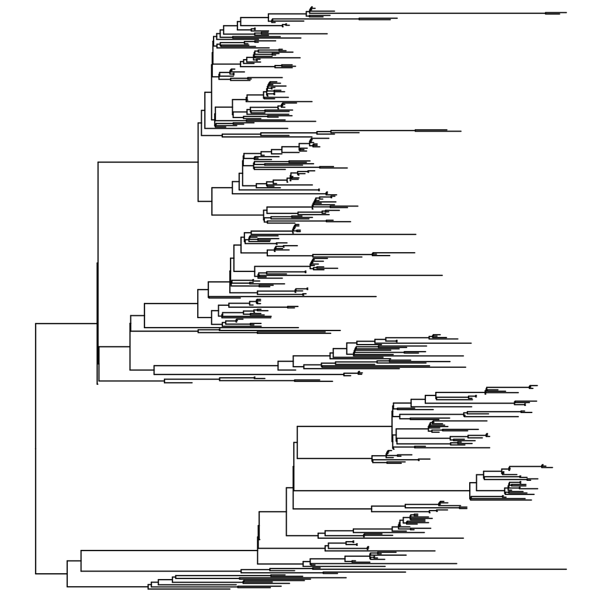

```r
tr <- phyloAMR::tr
ggtree(tr)
```

# Part 0: Visualization of the trait across the phylogenetic tree

Before performing ancestral state reconstruction, it is critical to visualize the tip states of the trait on the phylogeny.

Our ancestral state reconstruction and clustering algorithm is most powerful in settings where frequent emergence and spread of a trait occurs.

Notice the clustering of colistin non-susceptibility across the phylogeny.

- Numerous emergence events at ancestral nodes and tips can be visually inferred in this phylogeny
- Ancestral emergence events likely had noticeable variations in size. For instance, consider the large cluster of non-susceptibility in the above clade
- While we could visually categorize our data, we implemented an ancestral state reconstruction tool to characterize the data.

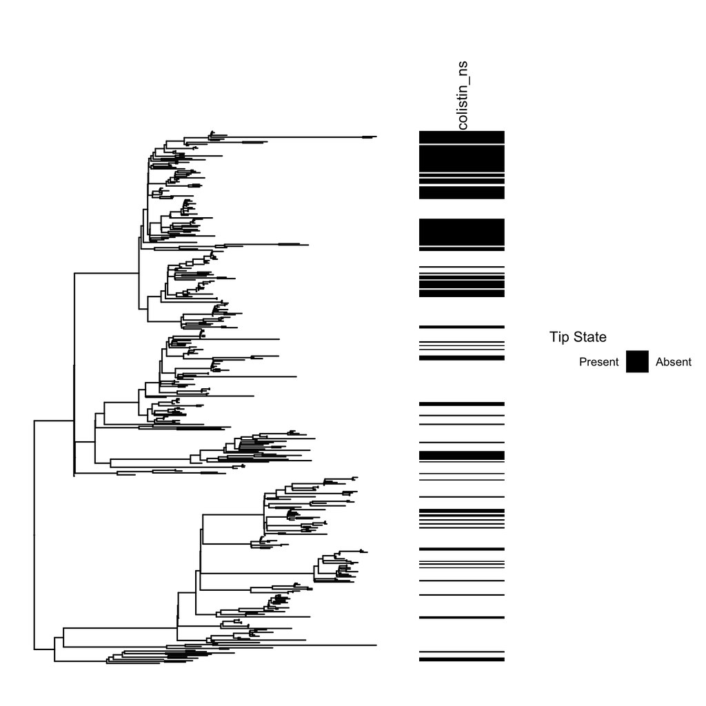

```r
feature_colors <- c(`1` = "black",`0`="white")
feature_scale <- scale_fill_manual(values=feature_colors,labels=c("Present","Absent"),name="Tip State", guide = guide_legend(nrow=1, title.position = "top", label.position = "right"))

p0 <- gheatmap(ggtree(tr),df %>% select(colistin_ns) %>% mutate_all(as.factor),colnames_position = 'top',width = .25,low = 'white',high='black',colnames_angle = 90,legend_title = 'Colistin non-susceptibility',hjust = 0,color = NULL) + ylim(NA,485) + feature_scale
p0
```

# Part 1: Ancestral state reconstruction to characterize colistin resistance

## Step 1: Run ancestral state reconstruction

- The workhorse function, asr(), is used to perform ancestral state reconstruction. This wrapper function implements ancestral state reconstruction with a single rate category using the corHMM R package: https://github.com/thej022214/corHMM
- Using inferred ancestral states and tip-based data, edges on the phylogenetic tree were evaluated to determine episodes where the trait continued (i.e., susceptible -> susceptible or non-susceptible -> non-susceptible), was gained (i.e., susceptible -> non-susceptible), or was lost (i.e., non-susceptible -> susceptible). This edge matrix can be leveraged for numerous applications, including characterizing the frequency of trait transitions across a phylogeny and investigating phenotype-genotype associations.
- The following parameters exist for this function
  - **df:** Dataframe with tip name variable (e.g., tip_name_var) and trait variable (e.g., colistin_ns)
  - **tr:** Phylogenetic tree object of class phylo
  - **model:** This approach permits the use of either the equal rates (ER) or the all rates differ (ARD) transition matrices.
    - Equal rates (ER): Assumes equal transition rates for trait gain (e.g., trait absence -> presence) or loss (e.g., trait gain -> absence)
    - All rates differ (ARD): Assumes different transition rates for trait gain and loss
  - node_states: Whether to perform ‘joint’ or ‘marginal’ ancestral state reconstruction
    - From our experience, we recommend using joint ancestral state reconstruction.

```r
asr_obj <- phyloAMR::asr(df = df,tr = tr,tip_name_var = "tip_name_var",pheno = "colistin_ns",model = "ER",node_states = "joint")
```

```
#> You specified 'fixed.nodes=FALSE' but included a phy object with node labels. These node labels have been removed.
#> State distribution in data:
#> States:  0   1
#> Counts:  277 136
#> Beginning thorough optimization search -- performing 0 random restarts
#> Finished. Inferring ancestral states using joint reconstruction.
```

```r
paste0("Output names: ")
```

```
#> [1] "Output names: "
```

```r
names(asr_obj)
```

```
#> [1] "corHMM_out"           "corHMM_model_summary" "parent_child_df"
#> [4] "node_states"
```

```r
paste0("corHMM_out: output from ancestral state reconstruction algorithm hosted in the R package corHMM")
```

```
#> [1] "corHMM_out: output from ancestral state reconstruction algorithm hosted in the R package corHMM"
```

```r
asr_obj$corHMM_out
```

```
#>
#> Fit
#>        lnL      AIC    AICc Rate.cat ntax
#>  -177.9706 357.9413 357.951        1  413
#>
#> Legend
#> [1] "colistin_ns"
#> [1] "0" "1"
#>
#> Rates
#>          0        1
#> 0       NA 89544.82
#> 1 89544.82       NA
#>
#> Arrived at a reliable solution
```

```r
paste0("corHMM_model_summary: A summary of the corHMM model, including the number of parameters, model, number of rate categories, inferred transition rates, log likelihood, AIC, and AICc")
```

```
#> [1] "corHMM_model_summary: A summary of the corHMM model, including the number of parameters, model, number of rate categories, inferred transition rates, log likelihood, AIC, and AICc"
```

```r
paste0("Rate 1 = transitions from level 1 (i.e., susceptible) to level 2 (i.e., non-susceptible)")
```

```
#> [1] "Rate 1 = transitions from level 1 (i.e., susceptible) to level 2 (i.e., non-susceptible)"
```

```r
paste0("Rate 2 = transitions from level 2 (i.e., non-susceptible) to level 1 (i.e., susceptible)")
```

```
#> [1] "Rate 2 = transitions from level 2 (i.e., non-susceptible) to level 1 (i.e., susceptible)"
```

```r
asr_obj$corHMM_model_summary
```

```
#>   model np nRateCat    rate1 rate2    loglik      AIC    AICc
#> 1    ER  1        1 89544.82    NA -177.9706 357.9413 357.951
```

```r
paste0("node_states: Chosen node state that was modeled.")
```

```
#> [1] "node_states: Chosen node state that was modeled."
```

```r
asr_obj$node_states
```

```
#> [1] "joint"
```

```r
paste0("parent_child_df: Parent child dataframe, which contains the edge dataset, parent and child values, the child name (for tips), and transition data (i.e., gain, loss, and continuation of the trait on tree or continuation of trait absence on tree)")
```

```
#> [1] "parent_child_df: Parent child dataframe, which contains the edge dataset, parent and child values, the child name (for tips), and transition data (i.e., gain, loss, and continuation of the trait on tree or continuation of trait absence on tree)"
```

```r
head(asr_obj$parent_child_df)
```

```
#>   parent child parent_val child_val child_name transition gain loss
#> 1    414   415          0         0       <NA>          0    0    0
#> 2    415   416          0         0       <NA>          0    0    0
#> 3    416   417          0         0       <NA>          0    0    0
#> 4    417   418          0         1       <NA>          1    1    0
#> 5    418   419          1         1       <NA>          0    0    0
#> 6    419   420          1         1       <NA>          0    0    0
#>   continuation continuation_present continuation_absent
#> 1            1                    0                   1
#> 2            1                    0                   1
#> 3            1                    0                   1
#> 4            0                    0                   0
#> 5            1                    1                   0
#> 6            1                    1                   0
```

## Step 2: Characterize the transition statistics for the trait across the phylogeny

The frequency and location of trait gain, loss, and continuation events can be characterized using the **asr_transition_analysis()** function

In this case, several important observations occur:

1. Of 824 edges, 48 contained transition events: 37 gain events and 11 loss events
2. Inference of location of these transition events revealed numerous events at the tips:
   1. 30/37 gain events
   2. 7/11 loss events
3. The number of gain events and large number of non-susceptible isolates not accounted for by gain events at the tip, suggest potential for inferred gain events to be shared across isolates.
   1. This is indicative of the emergence and spread of colistin non-susceptible strains in this population
4. We also provide frequency statistics for the gain, loss, and continuation of these traits that can be useful to characterize the transition dynamics of this trait:

```r
asr_transition_analysis(asr_obj$parent_child_df,node_states='joint')
```

```
#>   total_edges transitions gains gains_tip losses losses_tip continuations
#> 1         824          48    37        30     11          7           776
#>   continuations_present continuations_absent gain_frequency loss_frequency
#> 1                   209                  567           6.13              5
#>   continuation_present_frequency continuation_absent_frequency
#> 1                          25.36                         68.81
```

## Sidebar: Visualization on the phylogenetic tree

It is often helpful to visualize ancestral states on the phylogenetic tree, we build the function paint_tree_with_states() to visualize the edge matrix on the tree.

Very useful to understand the ancestral states of the traits.

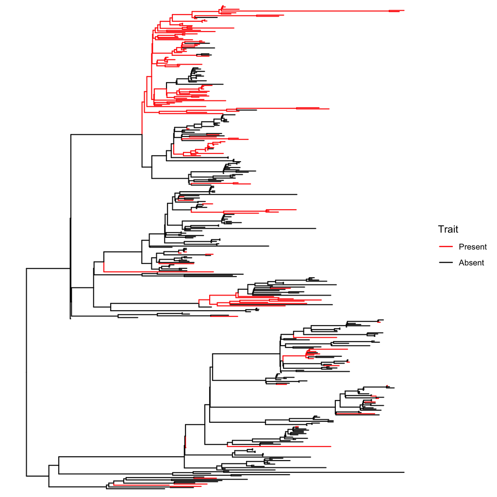

```r
painted_tree <- phyloAMR::paint_tree_with_states(asr_obj$parent_child_df,tr)
painted_tree
```

## Step 3: Cluster detection

Given the numerous gain and loss events, we are well-positioned to leverage our tree traversal algorithm to infer the evolutionary history of our isolates.

In this package, we developed a phylogenetic tree traversal algorithm, **asr_cluster_detection()**, that traces the ancestral states of each isolate to infer their evolutionary history. This algorithm takes an isolate’s trait data and walks upward on the tree to classify trait-containing isolates as phylogenetic singletons (i.e., evidence of de novo evolution) or members of a phylogenetic cluster of the trait (i.e., evidence of acquisition of a circulating trait-containing lineage).

Extending this to the study of Colistin non-susceptibility, non-susceptible isolates with gain events inferred at the tip were classified as phylogenetic singletons. However, instances where a non-susceptible isolate had a gain event at the tip and a reversion event at its parental node were eligible for classification as members of a phylogenetic cluster. Non-susceptible isolates were classified as members of a phylogenetic cluster if their ancestral gain event was shared with at least one additional resistant isolate. Non-susceptible isolates that did not share an ancestral gain event with any other resistant isolate were classified as phylogenetic singletons. Phylogenetic clusters where all isolates belonged to one patient were not considered clusters and were reclassified as redundant phylogenetic singletons.

**The following parameters exist for this function:**

- **df:** Dataframe with tip name variable (e.g., tip_name_var) and trait variable (e.g., colistin_ns)
- **tr:** Phylogenetic tree object of class phylo
- **tip_name_var:** Tip name variable
- **patient_id:** Variable pertaining to a patient identifier
- **pheno:** Phenotype of interest (e.g., colistin non-susceptibility)
- **parent_child_df:** The parent child dataframe (e.g., edge matrix)
- **node_states:** Node states of the ancestral state reconstruction model
- **confidence:** FOR MARGINAL RECONSTRUCTION, ONLY. Whether to only consider ‘high’ confidence events (e.g., absent to present) or ‘low’ confidence transition events (e.g., absent to unsure). We recommend using ‘high’ confidence transition events.
- **faux_clusters:** Whether to ‘remove’ (e.g., reclassify as singletons) or ‘rename’ (e.g., classify as faux) clusters where isolates belong to just one patient. This is important to consider when classifying clusters of this phenotype
- **remove_reverant:** Whether to remove (TRUE) the episodes of trait reversion (e.g., present -> absent) or permit them to be labeled
- **collapse_cluster:** Whether to collapse (TRUE) the episodes as either cluster, singleton, or no feature

```r
asr_cluster_obj <- asr_cluster_detection(df = df,tr=tr,tip_name_var = "tip_name_var",patient_id = 'PatientID',pheno = 'colistin_ns',parent_child_df = asr_obj$parent_child_df,node_states = 'joint',confidence = NULL,faux_clusters = 'remove',remove_revertant = TRUE,collapse_cluster = TRUE)

paste0("Cluster detection dataframe")
```

```
#> [1] "Cluster detection dataframe"
```

```r
colnames(asr_cluster_obj)
```

```
#>  [1] "parent"                "child"                 "parent_val"
#>  [4] "child_val"             "child_name"            "transition"
#>  [7] "gain"                  "loss"                  "continuation"
#> [10] "continuation_present"  "continuation_absent"   "asr_cluster"
#> [13] "asr_cluster_renamed"   "asr_cluster_collapsed"
```

```r
head(asr_cluster_obj,n=5)
```

```
#>           parent child parent_val child_val child_name transition gain loss
#> PCMP_H325    432     1          1         1  PCMP_H325          0    0    0
#> PCMP_H411    432     2          1         1  PCMP_H411          0    0    0
#> PCMP_H213    434     3          1         1  PCMP_H213          0    0    0
#> PCMP_H286    435     4          1         1  PCMP_H286          0    0    0
#> PCMP_H387    435     5          1         1  PCMP_H387          0    0    0
#>           continuation continuation_present continuation_absent asr_cluster
#> PCMP_H325            1                    1                   0 cluster_418
#> PCMP_H411            1                    1                   0 cluster_418
#> PCMP_H213            1                    1                   0 cluster_418
#> PCMP_H286            1                    1                   0 cluster_418
#> PCMP_H387            1                    1                   0 cluster_418
#>           asr_cluster_renamed asr_cluster_collapsed
#> PCMP_H325           Cluster 1               Cluster
#> PCMP_H411           Cluster 1               Cluster
#> PCMP_H213           Cluster 1               Cluster
#> PCMP_H286           Cluster 1               Cluster
#> PCMP_H387           Cluster 1               Cluster
```

```r
paste0("asr_cluster: raw clustering data. The numbers for cluster and revertant lineages correspond to the ancestral node where the shared gain (i.e., cluster_527) or loss (e.g., revertant_782) event occured.")
```

```
#> [1] "asr_cluster: raw clustering data. The numbers for cluster and revertant lineages correspond to the ancestral node where the shared gain (i.e., cluster_527) or loss (e.g., revertant_782) event occured."
```

```r
table(asr_cluster_obj$asr_cluster)
```

```
#>
#>   cluster_418   cluster_527   cluster_533   cluster_551   cluster_574
#>            72             2            12             2             8
#>   cluster_647   cluster_775    no feature revertant_464 revertant_476
#>             4             6           236             2            15
#> revertant_583 revertant_782 revertant_tip     singleton
#>            15             2             7            30
```

```r
paste0("asr_cluster_renamed: Renamed these categories as singleton, cluster X, and no feature")
```

```
#> [1] "asr_cluster_renamed: Renamed these categories as singleton, cluster X, and no feature"
```

```r
table(asr_cluster_obj$asr_cluster_renamed)
```

```
#>
#> No Feature  Singleton  Cluster 1  Cluster 2  Cluster 3  Cluster 4  Cluster 5
#>        277         30         72          2         12          2          4
#>  Cluster 6  Cluster 7
#>          8          6
```

```r
paste0("asr_cluster_collapsed: Collapsed as singleton, cluster, or no feature")
```

```
#> [1] "asr_cluster_collapsed: Collapsed as singleton, cluster, or no feature"
```

```r
table(asr_cluster_obj$asr_cluster_collapsed)
```

```
#>
#>    Cluster No Feature  Singleton
#>        106        277         30
```

## Step 4: Cluster statistics

To characterize the evolutionary history, we described both the transitional data and the phylogenetic clustering of each antibiotic phenotype.

Descriptive statistics for the phylogenetic clustering can be determined using phyloAMR’s **asr_cluster_analysis()** function.

Specifically, the crude frequency of the trait, descriptive statistics on the number of singletons, clusters, and summary statistics for cluster size.

We use two measures to characterize the phylogenetics of a trait: phylogenetic occurrence (**Equation 1**) and clustering (**Equation** **2**).

```r
asr_cluster_analysis(asr_cluster_obj,remove_faux = TRUE)
```

```
#>   present singletons clusters cluster_isolates cluster_size_median
#> 1     136         30        7              106                   6
#>   cluster_size_mean cluster_size_range no_feature revertant_isolates
#> 1             15.14               2-72        277                 41
#>   revertant_lineages revertant_lineage_size_median revertant_lineage_size_mean
#> 1                  4                           8.5                         8.5
#>   revertant_lineage_size_range phylogenetic_events feature_frequency
#> 1                         2-15                  37             32.93
#>   phylogenetic_frequency clustering_frequency
#> 1                   7.41                18.92
```

## Step 5: Visualize clusters on phylogeny

Finally, it is critical to inspect the lineages on the phylogeny.

Here is a tour of the phylogeny:

- White indicates susceptibility
- Red indicates non-susceptible isolate where gain was inferred at tip
  - Faux clusters (e.g., phylogenetic clusters from one patient) are also relabeled as red
- Other colors correspond to the seven clusters of Colistin non-susceptibility present in this population

This visualization permits the inspection of cluster calls and characterize the phylogenetic clustering of our trait using ancestral state reconstruction

- For instance, look at the large clusters in the top clade versus the bottom clade.
- This hints at a potential association between a shared genotype and these large clusters.

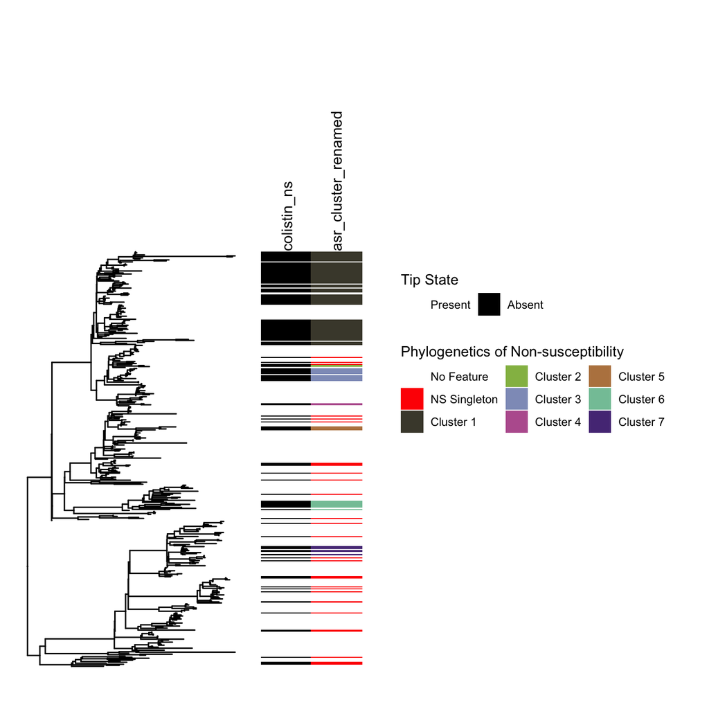

```r
# Cluster color pallete
## Number of clusters
ncluster <- table(asr_cluster_obj$asr_cluster)  %>% subset(names(.) != "singleton" & grepl("cluster",names(.))) %>% as.numeric %>%length
## Cluster pallete
color_palette <- grDevices::colors() %>% subset(grepl("red",.)==F)
clusters_col <- hues::iwanthue(ncluster,hmin=15,hmax=360,lmin = 5,lmax = 95,cmin=5,cmax=90,random = F,plot = F)
## Names
clusters_name <- paste0("Cluster ",1:ncluster)
names(clusters_col) <- clusters_name
## Scale
cluster_scale <- scale_fill_manual(breaks =c("No Feature","Singleton",names(clusters_col)),values=c("No Feature" = "white","Singleton" = "red",clusters_col),labels=c("No Feature","NS Singleton",clusters_name),name="Phylogenetics of Non-susceptibility", guide = guide_legend(ncol=4, title.position = "top", label.position = "right"))

# Phylogenetic visualization
p0.1 <- p0 +ggnewscale::new_scale_fill()
p1 <- gheatmap(p0.1,asr_cluster_obj %>% select(asr_cluster_renamed) %>% mutate_all(as.factor),colnames_position = 'top',width = .25,colnames_angle = 90,legend_title = 'Colistin non-usceptibility',hjust = 0,offset=0.0000075,color=NULL) + ylim(NA,625) + cluster_scale
p1
```

# Part 2: Analysis of genotype and phenotype relationships

Inspection of the phylogenetic tree and clustering of colistin resistance indicates a potential association between the acquisition of resistance and genotypes. Whether it be the acquisition of genotypes and our singletons OR the synchronous or downstream acquisition of cluster-defining genotypes.

We will evaluate the following questions:

1. What genotypes are associated with resitance emergence and spread? Are there any genotypes associated with phylogenetic emergence or are there any downstream compensatory mutations?

The following algorithms will be performed:

1. synchronous_detection(): Calculate synchronous gain and loss events
2. downstream_gain_loss(): Calculate downstream gain and loss events

## Step 0 : Describe data

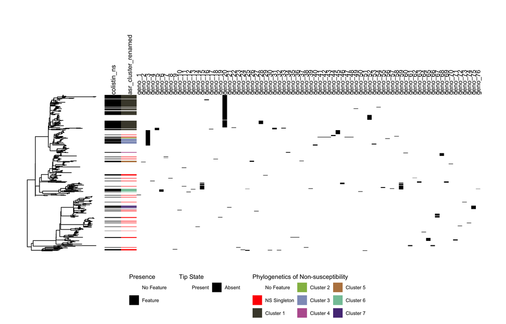

```r
genotype_mat <- phyloAMR::genotype_mat %>% mutate_all(as.numeric) %>% `colnames<-`(paste0("geno_",seq_len(ncol(.))))


presence <- scale_fill_manual(breaks =c(0,1),values=c("white","black"),labels=c("No Feature","Feature"),name="Presence", guide = guide_legend(ncol=1, title.position = "top", label.position = "right"))


p1.1 <- p1 + ggnewscale::new_scale_fill()
gheatmap(p1.1,genotype_mat %>% mutate_all(as.factor),colnames_position = 'top',width = 5,colnames_angle = 90,hjust = 0,offset=0.0000175,color=NULL,colnames = T) + ylim(NA,625)  + theme(legend.position = 'bottom') + presence
```

## Step 1: Generate ancestral state reconstruction

1. We performed ancestral state reconstruction on each individual genotype. It is best to attempt to parallelize this.
2. For downstream analyses, we will leverage and compare the parent_child_df matrices, which provide the gain and loss data for our traits.

```r
genotypes <- colnames(genotype_mat)
genotype_mat$tip_name_var <- rownames(genotype_mat)

genotypes_asr <- pbmcapply::pbmclapply(genotypes,FUN=function(x){
   phyloAMR::asr(df = genotype_mat,tr = tr,tip_name_var = "tip_name_var",pheno = x,model = "ER",node_states = "joint")
},mc.cores=5)

genotypes_asr_parent_child_df <- lapply(genotypes_asr,FUN=function(x){
  x$parent_child_df
})  %>% `names<-`(genotypes)
```

## Step 2: Are there genotypes that were synchronously gained or lost when the phenotype was gain/lost?

### Step 2a: Perform synchronous comparison

This algorithm looks for synchronous episodes where colistin and our genotypes both have a gain/loss event.

This method will be useful in evaluating resistance or reversion associated genotypes.

```r
synchronous_gain_loss_df <- pbmcapply::pbmclapply(genotypes_asr_parent_child_df,FUN=function(x){
  phyloAMR::synchronous_detection(x,asr_obj$parent_child_df)
},mc.cores=6) %>% do.call(rbind,.) %>% mutate(genotype = genotypes)
```

### Step 2b: Generate summary statistics

1. We have 22 genotypes that had gain events when the phenotype had a gain event
2. Interestingly, 3 genotypes were gained directly when the phenotype is lost. A potential reversion mutation

```r
table(synchronous_gain_loss_df$synchronous_gains_num,dnn="Number of synchronous gain events")
```

```
#> Number of synchronous gain events
#>  0  1  2
#> 54 21  1
```

```r
table(synchronous_gain_loss_df$synchronous_gain_loss_num,dnn="Number of synchronous gain + loss events")
```

```
#> Number of synchronous gain + loss events
#>  0
#> 76
```

```r
table(synchronous_gain_loss_df$synchronous_losses_num,dnn="Number of synchronous loss events")
```

```
#> Number of synchronous loss events
#>  0
#> 76
```

```r
table(synchronous_gain_loss_df$synchronous_loss_gain_num,dnn="Number of synchronous loss + genotype gain events")
```

```
#> Number of synchronous loss + genotype gain events
#>  0  1
#> 73  3
```

## Step 3: Evaluate downstream genotype events on stretches of the tree

### Step 3a: Perform downstream comparison

This algorithm identifies stretches on the tree where the colistin resistance is continued.

As we are intested in compensatory, reversion, or resistance mutations, we can look at these stretches for potential signature of resistance evolution

```r
downstream_df <- pbmcapply::pbmclapply(genotypes_asr_parent_child_df,FUN=function(x){
  comparitor_df <- x %>% as.data.frame
  phyloAMR::downstream_gain_loss(comparitor_parent_child_df = comparitor_df,trait_parent_child_df = asr_obj$parent_child_df,tr=tr)
},mc.cores=6) %>% do.call(rbind,.) %>% mutate(genotype = genotypes)
```

### Step 3b: Generate summary statistics

1. We identify 19 genotypes that were gained on phenotypic stretches, these could include downstream compensatory mutations or the resistance-associated genotype that did not have a gain event that matched the upstream phenotype gain event.

```r
table(downstream_df$stretches_w_gains_num,dnn="Number of stretches with genotype gain events")
```

```
#> Number of stretches with genotype gain events
#>  0  1
#> 57 19
```

```r
table(downstream_df$stretches_w_losses_num,dnn="Number of stretches with genotype loss events")
```

```
#> Number of stretches with genotype loss events
#>  0
#> 76
```

## Step 4: Categorize genotypes

Next, we should categorize our genotypes:

1. Resistance gain-associated: Synchronous gain event of trait + genotype
2. Reversion-associated: Synchronous loss of trait + gain of genotype
3. Downtream gain-associated: Genotype gained on phenotype stretch

### Step 4.1: Get categories

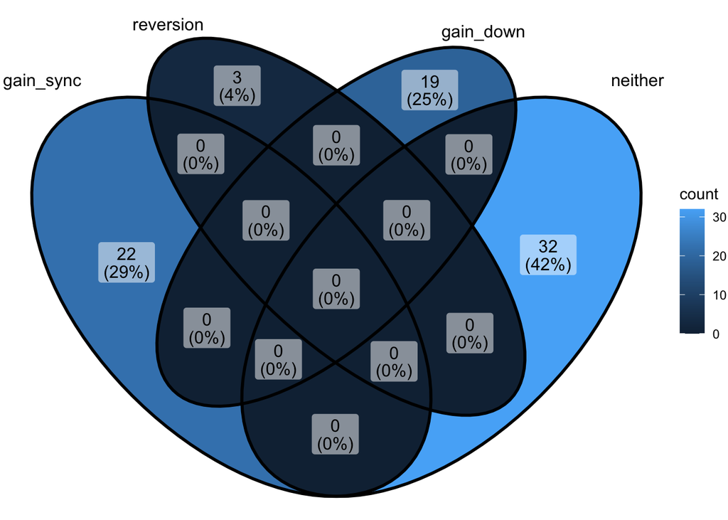

```r
gain_associated_genotypes <- synchronous_gain_loss_df %>% subset(synchronous_gains_num>0) %>% .$genotype
reversion_associated_genotypes <- synchronous_gain_loss_df %>% subset(synchronous_loss_gain_num>0) %>% .$genotype
downstream_gain_genotypes <- downstream_df %>% subset(stretches_w_gains_num>0) %>% .$genotype
not_characterized <- synchronous_gain_loss_df$genotype %>% subset(.,!. %in% c(gain_associated_genotypes,reversion_associated_genotypes,downstream_gain_genotypes))

genotypes_named <- c(rep('gain',length(gain_associated_genotypes)) %>% `names<-`(gain_associated_genotypes) ,rep('reversion',length(reversion_associated_genotypes)) %>% `names<-`(reversion_associated_genotypes) ,rep('downstream',length(downstream_gain_genotypes)) %>% `names<-`(downstream_gain_genotypes) ,rep('not categorized',length(not_characterized)) %>% `names<-`(not_characterized))

ggVennDiagram::ggVennDiagram(list(gain_sync=gain_associated_genotypes,reversion=reversion_associated_genotypes,gain_down = downstream_gain_genotypes,neither=not_characterized))
```

### Step 4.2: Add the genotype to the tree

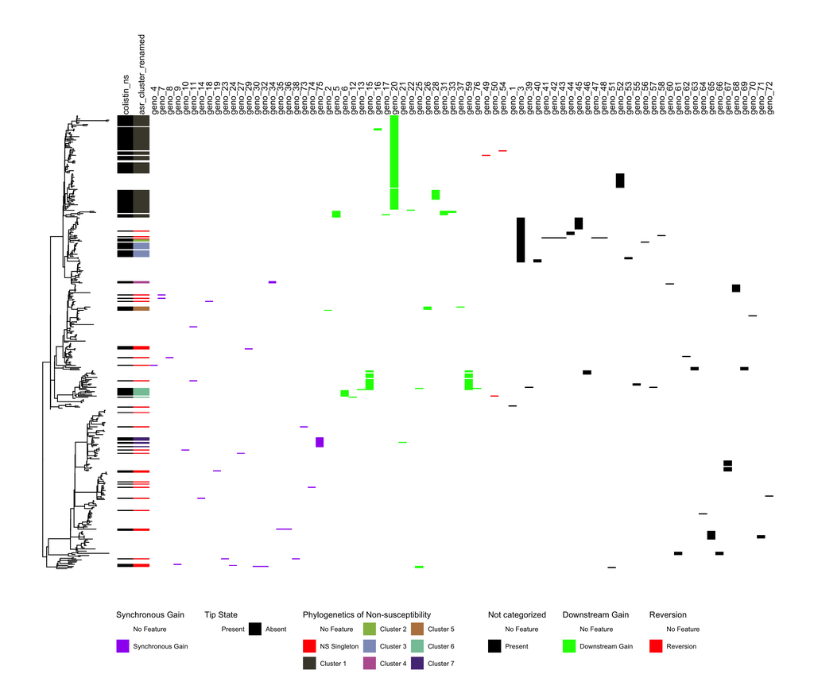

```r
gain <- scale_fill_manual(breaks =c(0,1),values=c("white","purple"),labels=c("No Feature","Synchronous Gain"),name="Synchronous Gain", guide = guide_legend(ncol=1, title.position = "top", label.position = "right"))
gain_down <- scale_fill_manual(breaks =c(0,1),values=c("white","green"),labels=c("No Feature","Downstream Gain"),name="Downstream Gain", guide = guide_legend(ncol=1, title.position = "top", label.position = "right"))
reversion <- scale_fill_manual(breaks =c(0,1),values=c("white","red"),labels=c("No Feature","Reversion"),name="Reversion", guide = guide_legend(ncol=1, title.position = "top", label.position = "right"))
not <- scale_fill_manual(breaks =c(0,1),values=c("white","black"),labels=c("No Feature","Present"),name="Not categorized", guide = guide_legend(ncol=1, title.position = "top", label.position = "right"))

rownames(genotype_mat) <- genotype_mat$tip_name_var

p1.1 <- p1 + ggnewscale::new_scale_fill()
p2 <- gheatmap(p1.1,genotype_mat %>% select(gain_associated_genotypes) %>% mutate_all(as.factor),colnames_position = 'top',width = 2.625,colnames_angle = 90,hjust = 0,offset=0.0000175,color=NULL,colnames = T) + ylim(NA,625) + gain + theme(legend.position = 'bottom')
p2.1 <- p2 + ggnewscale::new_scale_fill()
p3 <- gheatmap(p2.1,genotype_mat %>% select(downstream_gain_genotypes) %>% mutate_all(as.factor),colnames_position = 'top',width = 2.375,colnames_angle = 90,hjust = 0,offset=0.0001,color=NULL,colnames = T) + ylim(NA,625) + gain_down + theme(legend.position = 'bottom')
p3.1 <- p3 + ggnewscale::new_scale_fill()
p4 <- gheatmap(p3.1,genotype_mat %>% select(reversion_associated_genotypes) %>% mutate_all(as.factor),colnames_position = 'top',width = .375,colnames_angle = 90,hjust = 0,offset=0.000175,color=NULL,colnames = T) + ylim(NA,625) + reversion + theme(legend.position = 'bottom')
p4.1 <- p4 + ggnewscale::new_scale_fill()

p5 <- gheatmap(p4.1,genotype_mat %>% select(not_characterized) %>% mutate_all(as.factor),colnames_position = 'top',width = 4,colnames_angle = 90,hjust = 0,offset=0.0001875,color=NULL,colnames = T) + ylim(NA,490) + not + theme(legend.position = 'bottom')
p5
```

### Step 4.3: Characterize explanation of resistant strains with these synchronou and downstream gain events

```r
numerical_data <- function(variable,df){
  isolates_w_variant <- df %>% subset(get(variable) ==1)
  representation_in_clusters <-  table(isolates_w_variant %>% .$asr_cluster_renamed)
  true_cluster_size <- table(df %>% .$asr_cluster_renamed)

  res_prop_df <-lapply(names(true_cluster_size),FUN=function(x){
    if(x %in% names(representation_in_clusters) == F){
      prop =0
    }
    if(x %in% names(representation_in_clusters) == T){
      prop = representation_in_clusters[[x]] / true_cluster_size[[x]]
    }
    return(prop)
  }) %>% do.call(cbind.data.frame,.) %>% `colnames<-`(paste0(names(true_cluster_size),"_prop"))

  res_ct_df <-lapply(names(true_cluster_size),FUN=function(x){
    if(x %in% names(representation_in_clusters) == F){
      ct =0
    }
    if(x %in% names(representation_in_clusters) == T){
      ct = representation_in_clusters[[x]]
    }
    return(ct)
  }) %>% do.call(cbind.data.frame,.) %>% `colnames<-`(paste0(names(true_cluster_size),"_ct"))



  res_prop_df$Cluster_prop <- nrow(isolates_w_variant %>% subset(!asr_cluster_renamed %in% c("Singleton","No Feature"))) / nrow(df %>% subset(!asr_cluster_renamed %in% c("Singleton","No Feature")))
  res_ct_df$Cluster_ct <- nrow(isolates_w_variant %>% subset(!asr_cluster_renamed %in% c("Singleton","No Feature")))
  results <- cbind(res_prop_df,res_ct_df)
  return(results)
}
```

```r
genotype_mat <- left_join(genotype_mat,asr_cluster_obj %>% mutate(tip_name_var = child_name))
prop_data <- lapply(genotypes,numerical_data,df=genotype_mat) %>% do.call(rbind,.) %>% `rownames<-`(genotypes)
prop_columns <- colnames(prop_data) %>% subset(. != "Cluster_prop" & grepl("_prop",.)) %>% sort
ct_columns <- colnames(prop_data) %>% subset(. != "Cluster_ct" & grepl("_ct",.)) %>% sort
genotype_mat$asr_cluster_renamed <- factor(genotype_mat$asr_cluster_renamed,levels = c(prop_columns %>% gsub("_prop","",.)))
total_ct <-  table(genotype_mat %>% .$asr_cluster_renamed)
total_genotype_ct <- prop_data %>% select(ct_columns) %>% `colnames<-`(gsub("_ct","",colnames(.))) %>% rowSums()
column_names <- prop_columns %>% gsub("_prop","",.) %>% paste0(.," (n=",total_ct,")")
ct_matrix <-  prop_data %>% select(ct_columns) %>% `colnames<-`(gsub("_ct","",colnames(.)))  %>% round(.,0)  %>% as.matrix %>% {ifelse(. ==0,"",.)}

prop_matrix <- prop_data %>% select(prop_columns) %>% `colnames<-`(gsub("_prop","",colnames(.))) %>% round(.,3) %>% as.matrix
```

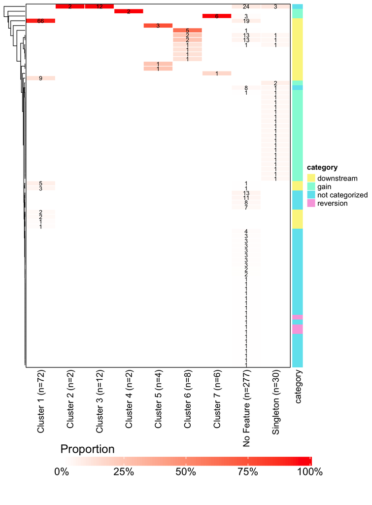

```r
# Legend
one_hundred_breaks <- c()
for(i in 1:100){
  one_hundred_breaks[i] <- 1*i
}

fig_legend <- ComplexHeatmap::Legend(at = c(0, 0.25, 0.50, 0.75, 1.00),labels = c("0%", "25%", "50%", "75%", "100%"),title = "Proportion",direction = "horizontal",col_fun = colorRamp2(breaks = c(0, 1.00),colors = c("white","red")), title_gp = gpar(fontsize = 16),labels_gp=gpar(fontsize=14),legend_width = unit(12, "cm"))

genotype_names <- genotypes_named  %>% as.data.frame %>% `colnames<-`("category")
genotype_names$genotype <- rownames(genotype_names)
prop_matrix <- left_join(prop_matrix %>% as.data.frame %>% mutate(genotype = rownames(.)),genotype_names)
rowannot <-  rowAnnotation(category = prop_matrix$category)
# Heatmap
A_heatmap <- ComplexHeatmap::Heatmap(prop_matrix %>% select(-genotype,-category),show_heatmap_legend = F,show_row_names = T,col = c("white","red"),cluster_columns = F,cluster_rows=T,name = "Proportion",column_labels = column_names,  cell_fun = function(j, i, x, y, width, height, fill) {
    grid.text(sprintf("%.3s", ct_matrix[i, j]), x, y, gp = gpar(fontsize = 8))
},border_gp = gpar(col = "black", lty = 1), rect_gp = gpar(col = "white", lwd = 1),right_annotation = rowannot)
fig_heatmap_image <- grid.grabExpr(draw(A_heatmap))
fig_legend_image <- grid.grabExpr(draw(fig_legend))

A <- cowplot::plot_grid(fig_heatmap_image,NULL,fig_legend_image,ncol=1,axis="l", align="hv",rel_heights = c(1,-.085,.2))
A
```

# Conclusion: